# INFSCI 2595 Fall 2021 - Final Project

Part iv: Complete problem classification – ivB)

Jianwei Liu

2021/11/6

```r
library(tidyverse)
```

```r
library(coefplot)
library(tidymodels)
library(glmnet)
library(nnet)
library(ranger)
library(xgboost)
library(kernlab)
library(finetune)
library(kknn)
library(vip)
if(parallel::detectCores(logical=FALSE) > 3){
  library(doParallel)

  num_cores <- parallel::detectCores(logical=FALSE)
  cl <- makePSOCKcluster(num_cores - 1)
  registerDoParallel(cl)
}
train_v <- readr::read_csv("train_input_set_v.csv", col_names = TRUE)
train_outputs <- readr::read_csv("train_outputs.csv", col_names = TRUE)
ready_v_A <- train_v %>%
  left_join(train_outputs, by = 'run_id') %>%
  select(-run_id, -response)
```

# Part iv: Complete problem classification – ivA)

### Linear additive features

```r
set.seed(2021)
cv_folds <- vfold_cv(ready_v_A, v = 5, repeats = 3)

cv_folds
```

```
## #  5-fold cross-validation repeated 3 times
## # A tibble: 15 x 3
##    splits             id      id2
##    <list>             <chr>   <chr>
##  1 <split [1519/380]> Repeat1 Fold1
##  2 <split [1519/380]> Repeat1 Fold2
##  3 <split [1519/380]> Repeat1 Fold3
##  4 <split [1519/380]> Repeat1 Fold4
##  5 <split [1520/379]> Repeat1 Fold5
##  6 <split [1519/380]> Repeat2 Fold1
##  7 <split [1519/380]> Repeat2 Fold2
##  8 <split [1519/380]> Repeat2 Fold3
##  9 <split [1519/380]> Repeat2 Fold4
## 10 <split [1520/379]> Repeat2 Fold5
## 11 <split [1519/380]> Repeat3 Fold1
## 12 <split [1519/380]> Repeat3 Fold2
## 13 <split [1519/380]> Repeat3 Fold3
## 14 <split [1519/380]> Repeat3 Fold4
## 15 <split [1520/379]> Repeat3 Fold5
```

Define Performance metrics:

```r
my_metrics <- metric_set(accuracy, roc_auc, mn_log_loss)
```

Define linear models specification:

```r
glm_spec <- logistic_reg() %>%
  set_engine("glm")
```

Preprocess the additive model:

```r
bp_additive <- recipe(outcome ~ ., data = ready_v_A) %>%
  step_center(all_predictors()) %>%
  step_scale(all_predictors())

bp_additive
```

```
## Recipe
##
## Inputs:
##
##       role #variables
##    outcome          1
##  predictor         41
##
## Operations:
##
## Centering for all_predictors()
## Scaling for all_predictors()
```

Visualize the pre-processed inputs:

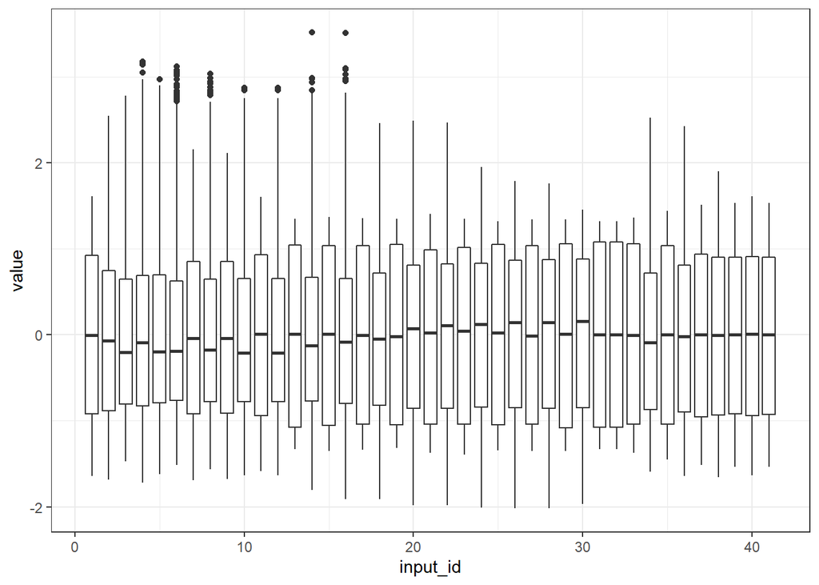

```r
bp_additive %>%
  prep(training = ready_v_A, retain = TRUE) %>%
  bake(new_data = NULL) %>%
  tibble::rowid_to_column() %>%
  pivot_longer(!c("rowid", "outcome")) %>%
  mutate(input_id = as.numeric(stringr::str_extract(name, '\\d+'))) %>%
  ggplot(mapping = aes(x = input_id, y = value)) +
  geom_boxplot(mapping = aes(group = input_id)) +
  theme_bw()
```

Compile the model and pre-processing into a single workflow:

```r
additive_wflow <- workflow() %>%
  add_model(glm_spec) %>%
  add_recipe(bp_additive)
```

Execute the training and testing:

```r
glm_add_res <- additive_wflow %>%
  fit_resamples(cv_folds,
                metrics = my_metrics,
                control = control_resamples(save_pred = TRUE))

glm_add_res %>% collect_metrics()
```

```
## # A tibble: 3 x 6
##   .metric     .estimator  mean     n std_err .config
##   <chr>       <chr>      <dbl> <int>   <dbl> <chr>
## 1 accuracy    binary     0.911    15 0.00211 Preprocessor1_Model1
## 2 mn_log_loss binary     0.211    15 0.00650 Preprocessor1_Model1
## 3 roc_auc     binary     0.973    15 0.00157 Preprocessor1_Model1
```

Display the confusion matrix:

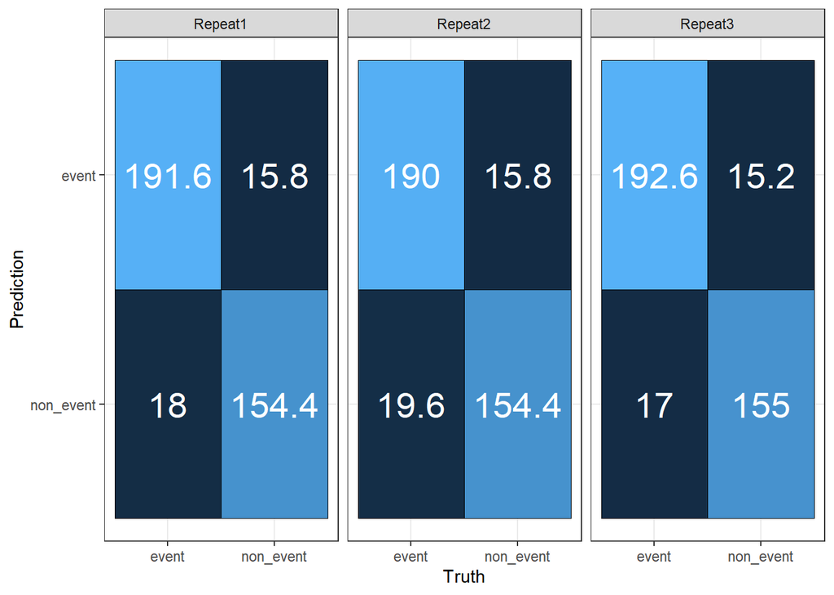

```r
glm_add_res %>% collect_predictions(summarize = FALSE) %>%
  group_nest(id, id2) %>%
  mutate(conf_mats = map(data,
                         ~ yardstick::conf_mat(.x, truth = outcome, estimate = .pred_class))) %>%
  mutate(conf_table = map(conf_mats, ~as.data.frame(.x$table))) %>%
  select(id, id2, conf_table) %>%
  tidyr::unnest(conf_table) %>%
  group_by(id, Prediction, Truth) %>%
  summarise(Freq = mean(Freq, na.rm = TRUE),
            .groups = 'drop') %>%
  mutate(Prediction = forcats::fct_rev(Prediction)) %>%
  ggplot(mapping = aes(x = Truth, y = Prediction)) +
  geom_tile(mapping = aes(fill = Freq),
            color = 'black') +
  geom_text(mapping = aes(label = round(Freq,2)),
            color = 'white', size = 7.5) +
  facet_wrap(~id) +
  theme_bw() +
  theme(legend.position = 'none')
```

Visualize the roc curve:

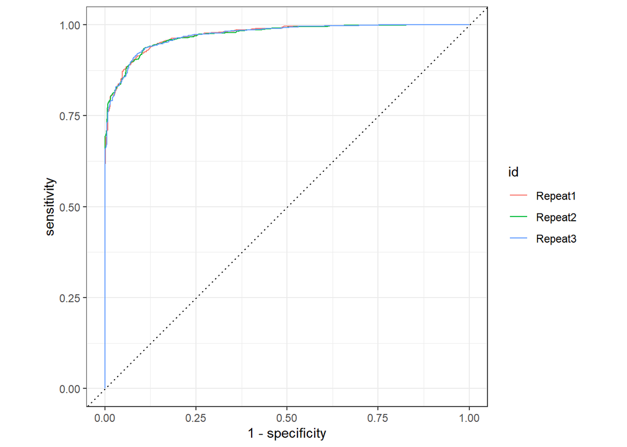

```r
glm_add_res %>% collect_predictions(summarize = FALSE) %>%
  group_by(id) %>%
  roc_curve(outcome, .pred_event) %>%
  autoplot()
```

### All pair-wise interactions between the inputs

Follow the same procedure:

```r
bp_pairs <- bp_additive %>%
  step_interact( ~ all_predictors():all_predictors())

glm_pairs_wflow <- workflow() %>%
  add_model(glm_spec) %>%
  add_recipe(bp_pairs)

glm_pairs_res <- glm_pairs_wflow %>%
  fit_resamples(cv_folds,
                metrics = my_metrics,
                control = control_resamples(save_pred = TRUE))

glm_pairs_res %>% collect_metrics()
```

```
## # A tibble: 3 x 6
##   .metric     .estimator  mean     n std_err .config
##   <chr>       <chr>      <dbl> <int>   <dbl> <chr>
## 1 accuracy    binary     0.764    15 0.00278 Preprocessor1_Model1
## 2 mn_log_loss binary     5.79     15 0.0763  Preprocessor1_Model1
## 3 roc_auc     binary     0.815    15 0.00349 Preprocessor1_Model1
```

Display the confusion matrix:

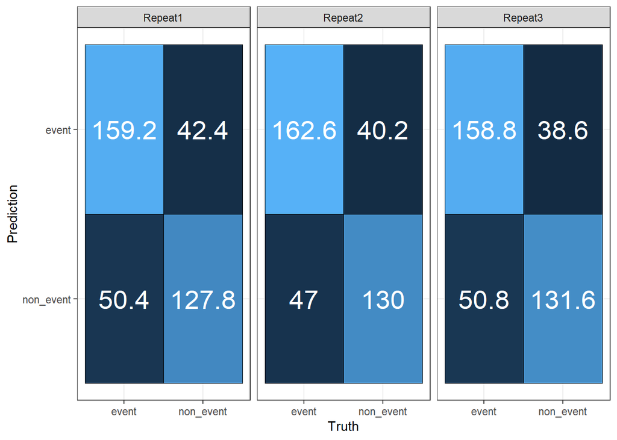

```r
glm_pairs_res %>% collect_predictions(summarize = FALSE) %>%
  group_nest(id, id2) %>%
  mutate(conf_mats = map(data,
                         ~ yardstick::conf_mat(.x, truth = outcome, estimate = .pred_class))) %>%
  mutate(conf_table = map(conf_mats, ~as.data.frame(.x$table))) %>%
  select(id, id2, conf_table) %>%
  tidyr::unnest(conf_table) %>%
  group_by(id, Prediction, Truth) %>%
  summarise(Freq = mean(Freq, na.rm = TRUE),
            .groups = 'drop') %>%
  mutate(Prediction = forcats::fct_rev(Prediction)) %>%
  ggplot(mapping = aes(x = Truth, y = Prediction)) +
  geom_tile(mapping = aes(fill = Freq),
            color = 'black') +
  geom_text(mapping = aes(label = round(Freq,2)),
            color = 'white', size = 7.5) +
  facet_wrap(~id) +
  theme_bw() +
  theme(legend.position = 'none')
```

Visualize the roc curve:

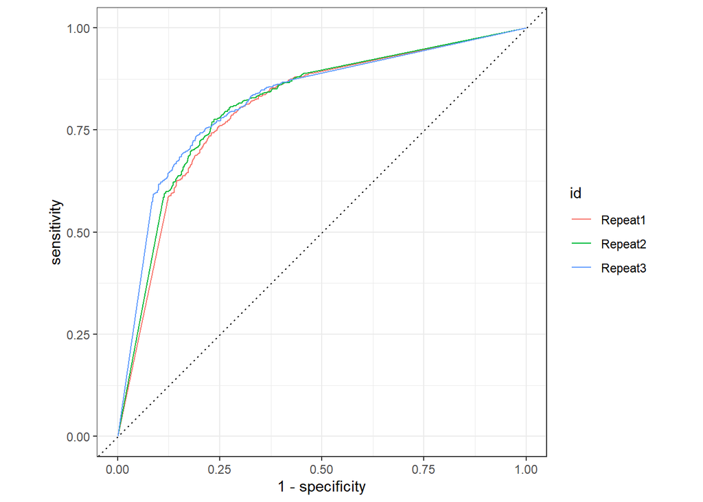

```r
glm_pairs_res %>% collect_predictions(summarize = FALSE) %>%
  group_by(id) %>%
  roc_curve(outcome, .pred_event) %>%
  autoplot()
```

### Add the linear models to summary:

```r
all_cv_results <- glm_add_res %>% collect_metrics(summarize = FALSE) %>%
  mutate(wflow_id = "glm_add") %>%
  bind_rows(glm_pairs_res %>% collect_metrics(summarize = FALSE) %>%
              mutate(wflow_id = "glm_pairs"))

all_cv_summaries  <- glm_add_res %>% collect_metrics(summarize = TRUE) %>%
  mutate(wflow_id = "glm_add") %>%
  bind_rows(glm_pairs_res %>% collect_metrics(summarize = TRUE) %>%
              mutate(wflow_id = "glm_pairs"))
```

### Penalized regression - Elastic net

#### All pair-wise interactions between the inputs

The above pair-wise model doesn’t perform really well. The reason is that there are two many features!

```r
model.matrix(outcome ~ (.)^2, ready_v_A) %>% dim()
```

```
## [1] 1899  862
```

We need to turn off unimportant inputs by using penalized regression with Elastic Net. First we use lasso to help us set the bound on lambda:

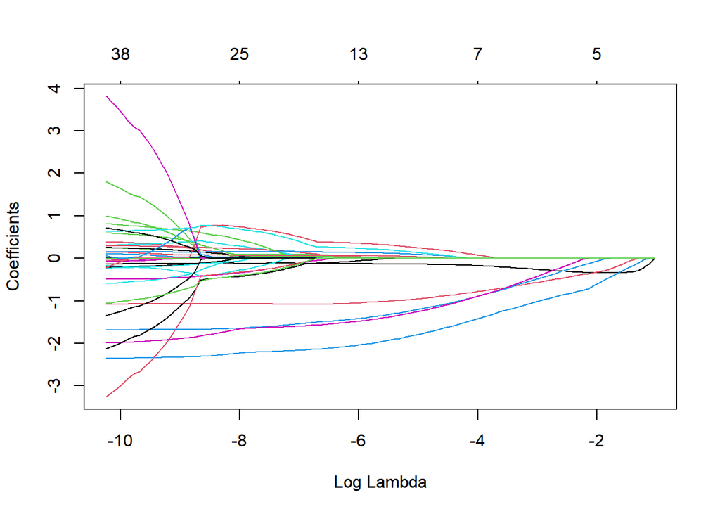

```r
lasso_for_fit <- logistic_reg(penalty = 0.1, mixture = 1) %>%
  set_engine("glmnet",
             intercept = TRUE, standardize = TRUE)

lasso_only_wflow <- workflow() %>%
  add_model(lasso_for_fit) %>%
  add_recipe(bp_additive)

lasso_only_fit <- lasso_only_wflow %>%
  fit(ready_v_A)

lasso_only_fit %>% extract_fit_parsnip() %>%
  pluck('fit') %>%
  plot(xvar = 'lambda')
```

```r
lasso_only_fit %>% extract_fit_parsnip() %>%
  pluck('fit') %>%
  broom:::tidy.glmnet() %>%
  distinct(lambda) %>%
  arrange(lambda) %>%
  pull() %>%
  log() %>%
  summary()
```

```
##    Min. 1st Qu.  Median    Mean 3rd Qu.    Max.
## -10.241  -7.939  -5.636  -5.636  -3.334  -1.031
```

Then we define the search grid:

```r
my_lambda <- penalty(range = c(-10, -1), trans = log_trans())
my_alpha <- mixture(range = c(0.1, 1.0))
enet_grid <- grid_regular(my_lambda, my_alpha,
                          levels = c(penalty = 75, mixture = 5))
```

Then we define the elastic net model:

```r
enet_spec <- logistic_reg(penalty = tune(), mixture = tune()) %>%
  set_engine("glmnet",
             intercept = TRUE, standardize = TRUE,
             path_values = exp(seq(-10, -1, length.out = 75)))
```

The workflow for all pair-wise interactions is defined below:

```r
enet_pairs_wflow <- workflow() %>%
  add_model(enet_spec) %>%
  add_recipe(bp_pairs)
```

Train and test the pairs elastic net:

```r
enet_pairs_res <- tune_grid(
  enet_pairs_wflow,
  resamples = cv_folds,
  grid = enet_grid,
  metrics = my_metrics
)
```

Visualize the result:

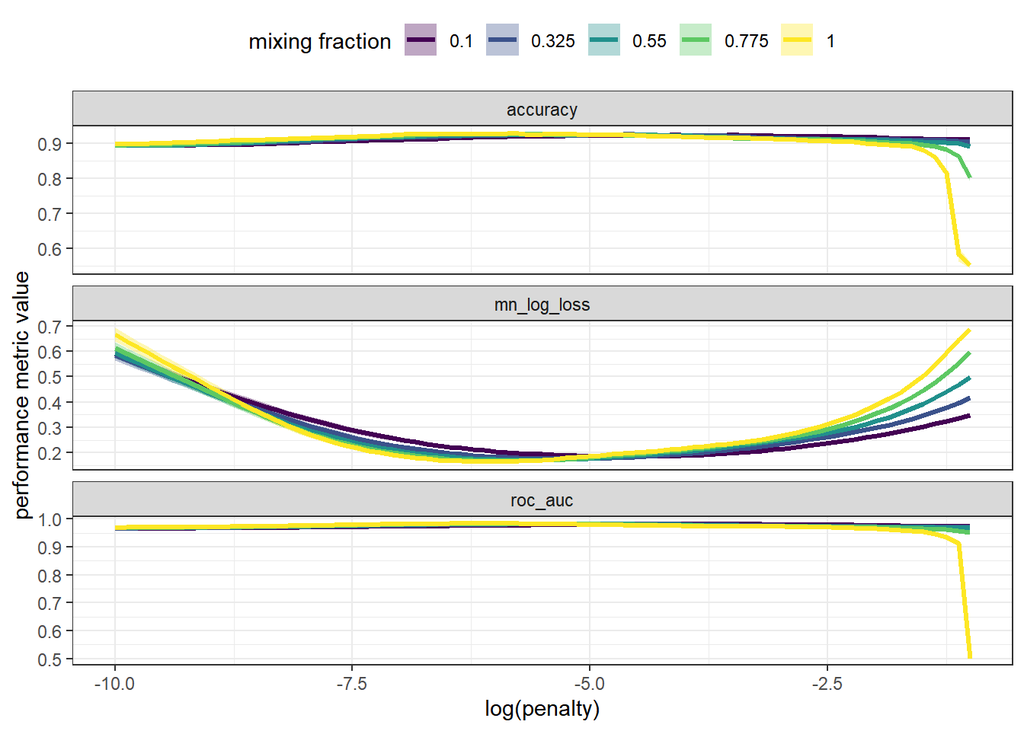

```r
enet_pairs_res %>% collect_metrics() %>%
  ggplot(mapping = aes(x = log(penalty))) +
  geom_ribbon(mapping = aes(ymin = mean - std_err,
                            ymax = mean + std_err,
                            group = interaction(mixture, .metric),
                            fill = as.factor(mixture)),
              alpha = 0.35) +
  geom_line(mapping = aes(y = mean,
                          group = interaction(mixture, .metric),
                          color = as.factor(mixture)),
            size = 1.15) +
  facet_wrap(~.metric, scales = "free_y", ncol = 1) +
  scale_fill_viridis_d("mixing fraction") +
  scale_color_viridis_d("mixing fraction") +
  labs(y = "performance metric value") +
  theme_bw() +
  theme(legend.position = "top")
```

Focus on ROC AUC and identify the best lambda using “1-standard error rule”:

```r
enet_pairs_res %>% select_by_one_std_err(desc(penalty), desc(mixture), metric = 'roc_auc')
```

```
## # A tibble: 1 x 10
##   penalty mixture .metric .estimator  mean     n std_err .config    .best .bound
##     <dbl>   <dbl> <chr>   <chr>      <dbl> <int>   <dbl> <chr>      <dbl>  <dbl>
## 1 0.00665    0.55 roc_auc binary     0.982    15 0.00146 Preproces~ 0.984  0.982
```

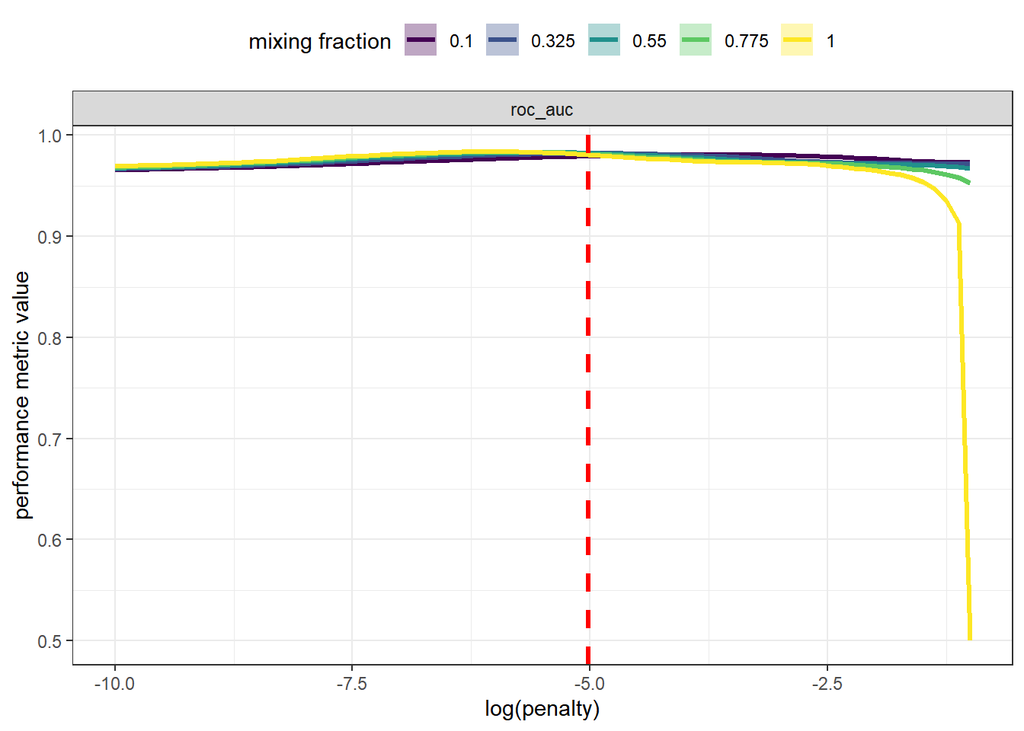

```r
enet_pairs_res %>% collect_metrics() %>%
  filter(.metric %in% c("roc_auc")) %>%
  ggplot(mapping = aes(x = log(penalty))) +
  geom_ribbon(mapping = aes(ymin = mean - std_err,
                            ymax = mean + std_err,
                            group = interaction(mixture, .metric),
                            fill = as.factor(mixture)),
              alpha = 0.35) +
  geom_line(mapping = aes(y = mean,
                          group = interaction(mixture, .metric),
                          color = as.factor(mixture)),
            size = 1.15) +
  geom_vline(data = enet_pairs_res %>% select_by_one_std_err(desc(penalty), desc(mixture), metric = 'roc_auc'),
             mapping = aes(xintercept = log(penalty)),
             color = 'red', linetype = 'dashed', size = 1.2) +
  facet_wrap(~.metric, scales = "free_y", ncol = 1) +
  scale_fill_viridis_d("mixing fraction") +
  scale_color_viridis_d("mixing fraction") +
  labs(y = 'performance metric value') +
  theme_bw() +
  theme(legend.position = "top")
```

The best tuning parameter set consists of a mixing fraction equal to 0.55.

Fit the pairs elastic net with the best tuning parameters:

```r
enet_pairs_best_roc_auc_params <- enet_pairs_res %>%
  select_by_one_std_err(desc(penalty), desc(mixture), metric = 'roc_auc') %>%
  select(all_of(names(enet_grid)))

final_enet_pairs_wflow <- enet_pairs_wflow %>%
  finalize_workflow(enet_pairs_best_roc_auc_params)

final_enet_pairs_fit <- final_enet_pairs_wflow %>%
  fit_resamples(cv_folds,
                metrics = my_metrics,
                control = control_resamples(save_pred = TRUE))
final_enet_pairs_fit %>% collect_metrics()
```

```
## # A tibble: 3 x 6
##   .metric     .estimator  mean     n std_err .config
##   <chr>       <chr>      <dbl> <int>   <dbl> <chr>
## 1 accuracy    binary     0.926    15 0.00306 Preprocessor1_Model1
## 2 mn_log_loss binary     0.177    15 0.00589 Preprocessor1_Model1
## 3 roc_auc     binary     0.982    15 0.00146 Preprocessor1_Model1
```

Display the confusion matrix:

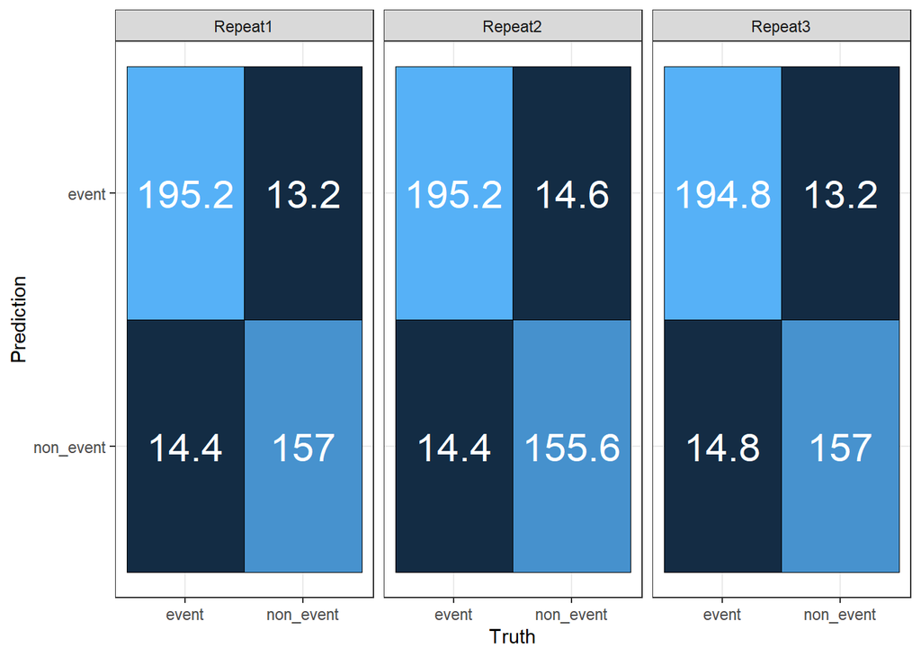

```r
final_enet_pairs_fit %>% collect_predictions(summarize = FALSE) %>%
  group_nest(id, id2) %>%
  mutate(conf_mats = map(data,
                         ~ yardstick::conf_mat(.x, truth = outcome, estimate = .pred_class))) %>%
  mutate(conf_table = map(conf_mats, ~as.data.frame(.x$table))) %>%
  select(id, id2, conf_table) %>%
  tidyr::unnest(conf_table) %>%
  group_by(id, Prediction, Truth) %>%
  summarise(Freq = mean(Freq, na.rm = TRUE),
            .groups = 'drop') %>%
  mutate(Prediction = forcats::fct_rev(Prediction)) %>%
  ggplot(mapping = aes(x = Truth, y = Prediction)) +
  geom_tile(mapping = aes(fill = Freq),
            color = 'black') +
  geom_text(mapping = aes(label = round(Freq,2)),
            color = 'white', size = 7.5) +
  facet_wrap(~id) +
  theme_bw() +
  theme(legend.position = 'none')
```

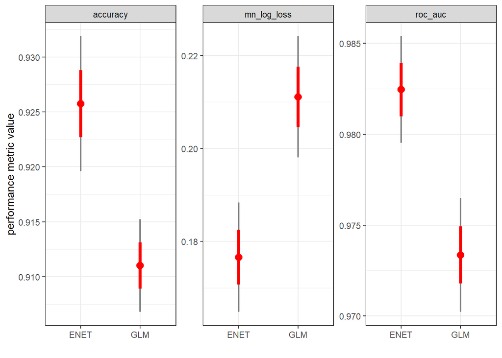

```r
glm_add_res %>% collect_metrics(summarize = TRUE) %>%
  mutate(wflow_id = "GLM") %>%
  bind_rows(final_enet_pairs_fit %>% collect_metrics(summarize = TRUE) %>%
              mutate(wflow_id = 'ENET')) %>%
  ggplot(mapping = aes(x = wflow_id)) +
  geom_linerange(mapping = aes(ymin = mean - 2*std_err,
                               ymax = mean + 2*std_err,
                               group = interaction(.metric, wflow_id)),
                 color = 'grey50', size = 0.75) +
  geom_linerange(mapping = aes(ymin = mean - 1*std_err,
                               ymax = mean + 1*std_err,
                               group = interaction(.metric, wflow_id)),
                 color = 'red', size = 1.45) +
  geom_point(mapping = aes(y = mean),
             color = 'red', size = 3.1) +
  facet_wrap(~.metric, scales = "free_y", nrow = 1) +
  labs(x = '', y = 'performance metric value') +
  theme_bw()
```

#### cubic RSM model with chosen interactions and basis features

Create the cubic RSM model with chosen interactions and basis features:

```r
bp_rsm3_small <- recipe(outcome ~ v01 + v02 + v04 + v06 + v08 + v10 + v12, data = ready_v_A) %>%
  step_center(all_predictors()) %>%
  step_scale(all_predictors()) %>%
  step_poly(all_predictors(), degree = 3,
            options = list(raw = TRUE)) %>%
  step_interact(~ends_with("_poly_1"):ends_with("_poly_1"):ends_with("_poly_1"))

glm_rsm3_small_wflow <- workflow() %>%
  add_model(glm_spec) %>%
  add_recipe(bp_rsm3_small)

glm_rsm3_small_res <- glm_rsm3_small_wflow %>%
  fit_resamples(cv_folds,
                metrics = my_metrics)

glm_rsm3_small_res %>% collect_metrics()
```

```
## # A tibble: 3 x 6
##   .metric     .estimator  mean     n std_err .config
##   <chr>       <chr>      <dbl> <int>   <dbl> <chr>
## 1 accuracy    binary     0.919    15 0.00352 Preprocessor1_Model1
## 2 mn_log_loss binary     0.212    15 0.0103  Preprocessor1_Model1
## 3 roc_auc     binary     0.976    15 0.00181 Preprocessor1_Model1
```

Train and test the rsm3 elastic net:

```r
enet_rsm3_wflow <- workflow() %>%
  add_model(enet_spec) %>%
  add_recipe(bp_rsm3_small)

enet_rsm3_res <- tune_grid(
  enet_rsm3_wflow,
  resamples = cv_folds,
  grid = enet_grid,
  metrics = my_metrics
)
```

Visualize the result:

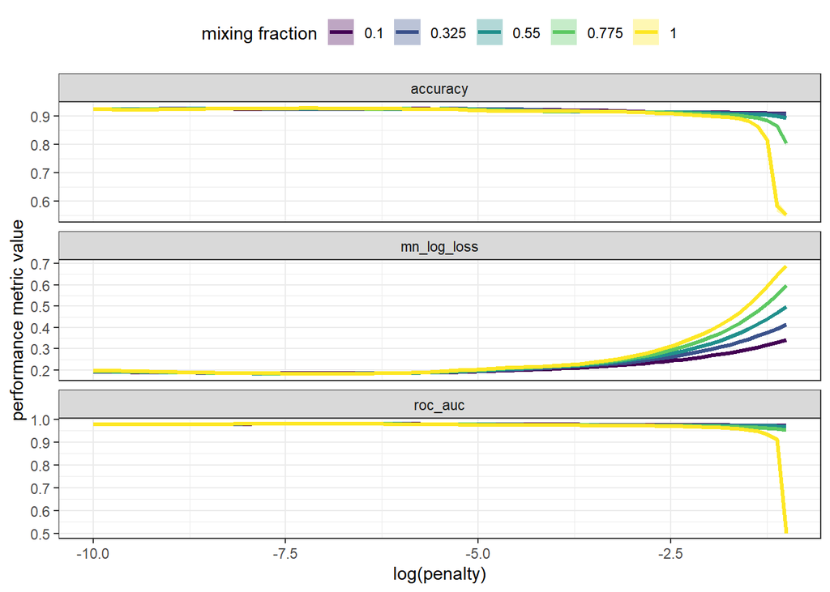

```r
enet_rsm3_res %>% collect_metrics() %>%
  ggplot(mapping = aes(x = log(penalty))) +
  geom_ribbon(mapping = aes(ymin = mean - std_err,
                            ymax = mean + std_err,
                            group = interaction(mixture, .metric),
                            fill = as.factor(mixture)),
              alpha = 0.35) +
  geom_line(mapping = aes(y = mean,
                          group = interaction(mixture, .metric),
                          color = as.factor(mixture)),
            size = 1.15) +
  facet_wrap(~.metric, scales = "free_y", ncol = 1) +
  scale_fill_viridis_d("mixing fraction") +
  scale_color_viridis_d("mixing fraction") +
  labs(y = "performance metric value") +
  theme_bw() +
  theme(legend.position = "top")
```

```r
enet_rsm3_res %>% select_best(metric = 'roc_auc')
```

```
## # A tibble: 1 x 3
##    penalty mixture .config
##      <dbl>   <dbl> <chr>
## 1 0.000745    0.55 Preprocessor1_Model174
```

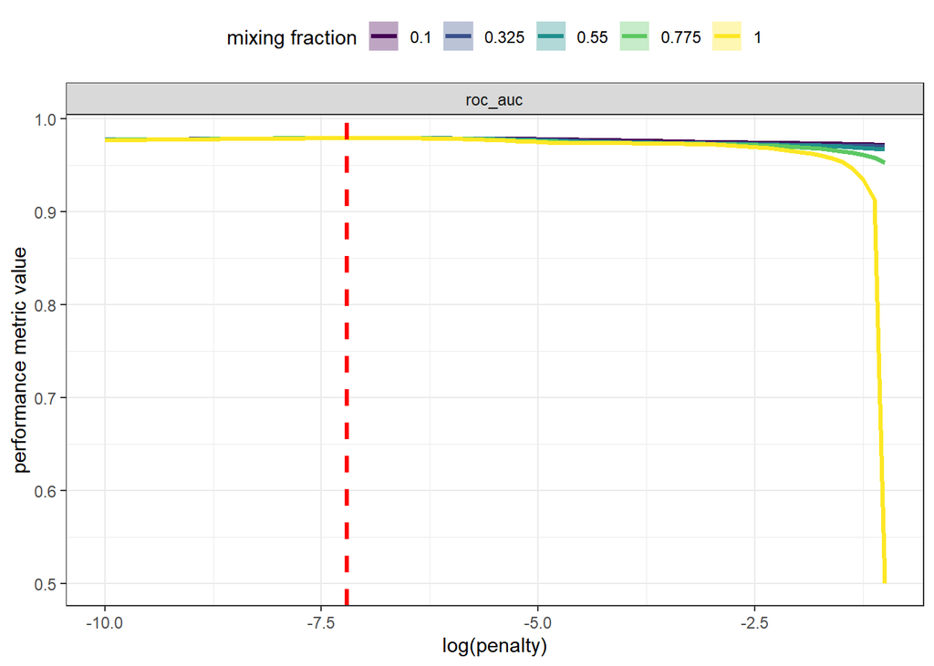

```r
enet_rsm3_res %>% collect_metrics() %>%
  filter(.metric %in% c("roc_auc")) %>%
  ggplot(mapping = aes(x = log(penalty))) +
  geom_ribbon(mapping = aes(ymin = mean - std_err,
                            ymax = mean + std_err,
                            group = interaction(mixture, .metric),
                            fill = as.factor(mixture)),
              alpha = 0.35) +
  geom_line(mapping = aes(y = mean,
                          group = interaction(mixture, .metric),
                          color = as.factor(mixture)),
            size = 1.15) +
  geom_vline(data = enet_rsm3_res %>% select_best(metric = 'roc_auc'),
             mapping = aes(xintercept = log(penalty)),
             color = 'red', linetype = 'dashed', size = 1.2) +
  facet_wrap(~.metric, scales = "free_y", ncol = 1) +
  scale_fill_viridis_d("mixing fraction") +
  scale_color_viridis_d("mixing fraction") +
  labs(y = 'performance metric value') +
  theme_bw() +
  theme(legend.position = "top")
```

Fit the rsm3 elastic net with the best tuning parameters:

```r
enet_rsm3_best_roc_params <- enet_rsm3_res %>%
  select_best(metric = 'roc_auc') %>%
  select(all_of(names(enet_grid)))

final_enet_rsm3_wflow <- enet_rsm3_wflow %>%
  finalize_workflow(enet_rsm3_best_roc_params)

final_enet_rsm3_fit <- final_enet_rsm3_wflow %>%
  fit_resamples(cv_folds,
                metrics = my_metrics)
final_enet_rsm3_fit %>% collect_metrics()
```

```
## # A tibble: 3 x 6
##   .metric     .estimator  mean     n std_err .config
##   <chr>       <chr>      <dbl> <int>   <dbl> <chr>
## 1 accuracy    binary     0.925    15 0.00266 Preprocessor1_Model1
## 2 mn_log_loss binary     0.184    15 0.00662 Preprocessor1_Model1
## 3 roc_auc     binary     0.979    15 0.00142 Preprocessor1_Model1
```

Add the result to all_cv_results:

```r
all_cv_results <- all_cv_results %>%
  bind_rows(enet_pairs_res %>% collect_metrics(summarize = FALSE) %>%
              mutate(wflow_id = "enet_pairs")) %>%
  bind_rows(enet_rsm3_res %>% collect_metrics(summarize = FALSE) %>%
              mutate(wflow_id = "enet_rsm3_small"))

all_cv_summaries <- all_cv_summaries %>%
  bind_rows(enet_pairs_res %>% collect_metrics(summarize = TRUE) %>%
              inner_join(enet_pairs_best_roc_auc_params %>%
                           mutate(keep_these = 'yes'),
                         by = names(enet_pairs_best_roc_auc_params)) %>%
              select(-keep_these) %>%
              mutate(wflow_id = "enet_pairs")) %>%
  bind_rows(enet_rsm3_res %>% collect_metrics(summarize = TRUE) %>%
              inner_join(enet_rsm3_best_roc_params %>%
                           mutate(keep_these = 'yes'),
                         by = names(enet_rsm3_best_roc_params)) %>%
              select(-keep_these) %>%
              mutate(wflow_id = "enet_rsm3_small"))
```

### Neural Network

Build neural network using mlp:

```r
nnet_spec <- mlp(hidden_units = tune(), penalty = tune(), epochs = 2000) %>%
  set_engine("nnet", MaxNWts = 2500, trace=FALSE) %>%
  set_mode("classification")
```

Define neural network workflow:

```r
nnet_wflow <- workflow() %>%
  add_model(nnet_spec) %>%
  add_recipe(bp_additive)
```

Tune the model using Bayesian optimization:

```r
nn_set <- parameters(nnet_wflow)
nn_set <- nn_set %>%
  update(hidden_units = hidden_units(c(0L, 30L)),
         penalty = penalty(c(-2L,2L)))

set.seed(2021)
nn_res <- nnet_wflow %>%
  tune_bayes(resamples = cv_folds,
             param_info = nn_set,
             initial = 5,
             iter = 30,
             metrics = my_metrics,
             control = control_bayes(no_improve = 10, verbose = TRUE))
```

```
## >  Generating a set of 5 initial parameter results
```

```
## √ Initialization complete
```

```
## Optimizing accuracy using the expected improvement
```

```
## -- Iteration 1 -----------------------------------------------------------------
```

```
## i Current best:      accuracy=0.9293 (@iter 0)
```

```
## i Gaussian process model
```

```
## √ Gaussian process model
```

```
## i Generating 5000 candidates
```

```
## i Predicted candidates
```

```
## i hidden_units=25, penalty=0.366
```

```
## i Estimating performance
```

```
## √ Estimating performance
```

```
## (x) Newest results:  accuracy=0.9263 (+/-0.00292)
```

```
## -- Iteration 2 -----------------------------------------------------------------
```

```
## i Current best:      accuracy=0.9293 (@iter 0)
```

```
## i Gaussian process model
```

```
## √ Gaussian process model
```

```
## i Generating 5000 candidates
```

```
## i Predicted candidates
```

```
## i hidden_units=0, penalty=1.05
```

```
## i Estimating performance
```

```
## x All models failed for: hidden_units=0, penalty=1.05
```

```
## x All models failed
```

```
## -- Iteration 3 -----------------------------------------------------------------
```

```
## i Current best:      accuracy=0.9293 (@iter 0)
```

```
## i Gaussian process model
```

```
## √ Gaussian process model
```

```
## i Generating 5000 candidates
```

```
## i Predicted candidates
```

```
## i hidden_units=1, penalty=1.05
```

```
## i Estimating performance
```

```
## √ Estimating performance
```

```
## (x) Newest results:  accuracy=0.9163 (+/-0.00303)
```

```
## -- Iteration 4 -----------------------------------------------------------------
```

```
## i Current best:      accuracy=0.9293 (@iter 0)
```

```
## i Gaussian process model
```

```
## √ Gaussian process model
```

```
## i Generating 5000 candidates
```

```
## i Predicted candidates
```

```
## i hidden_units=18, penalty=0.232
```

```
## i Estimating performance
```

```
## √ Estimating performance
```

```
## (x) Newest results:  accuracy=0.9168 (+/-0.00343)
```

```
## -- Iteration 5 -----------------------------------------------------------------
```

```
## i Current best:      accuracy=0.9293 (@iter 0)
```

```
## i Gaussian process model
```

```
## √ Gaussian process model
```

```
## i Generating 5000 candidates
```

```
## i Predicted candidates
```

```
## i hidden_units=21, penalty=0.513
```

```
## i Estimating performance
```

```
## √ Estimating performance
```

```
## (x) Newest results:  accuracy=0.9275 (+/-0.00317)
```

```
## -- Iteration 6 -----------------------------------------------------------------
```

```
## i Current best:      accuracy=0.9293 (@iter 0)
```

```
## i Gaussian process model
```

```
## √ Gaussian process model
```

```
## i Generating 5000 candidates
```

```
## i Predicted candidates
```

```
## i hidden_units=14, penalty=0.46
```

```
## i Estimating performance
```

```
## √ Estimating performance
```

```
## (x) Newest results:  accuracy=0.924 (+/-0.00301)
```

```
## -- Iteration 7 -----------------------------------------------------------------
```

```
## i Current best:      accuracy=0.9293 (@iter 0)
```

```
## i Gaussian process model
```

```
## √ Gaussian process model
```

```
## i Generating 5000 candidates
```

```
## i Predicted candidates
```

```
## i hidden_units=27, penalty=0.641
```

```
## i Estimating performance
```

```
## √ Estimating performance
```

```
## <3 Newest results:   accuracy=0.93 (+/-0.00322)
```

```
## -- Iteration 8 -----------------------------------------------------------------
```

```
## i Current best:      accuracy=0.93 (@iter 7)
```

```
## i Gaussian process model
```

```
## √ Gaussian process model
```

```
## i Generating 5000 candidates
```

```
## i Predicted candidates
```

```
## i hidden_units=28, penalty=0.6
```

```
## i Estimating performance
```

```
## √ Estimating performance
```

```
## (x) Newest results:  accuracy=0.9275 (+/-0.00349)
```

```
## -- Iteration 9 -----------------------------------------------------------------
```

```
## i Current best:      accuracy=0.93 (@iter 7)
```

```
## i Gaussian process model
```

```
## √ Gaussian process model
```

```
## i Generating 5000 candidates
```

```
## i Predicted candidates
```

```
## i hidden_units=21, penalty=0.684
```

```
## i Estimating performance
```

```
## √ Estimating performance
```

```
## <3 Newest results:   accuracy=0.9308 (+/-0.00381)
```

```
## -- Iteration 10 ----------------------------------------------------------------
```

```
## i Current best:      accuracy=0.9308 (@iter 9)
```

```
## i Gaussian process model
```

```
## √ Gaussian process model
```

```
## i Generating 5000 candidates
```

```
## i Predicted candidates
```

```
## i hidden_units=22, penalty=0.649
```

```
## i Estimating performance
```

```
## √ Estimating performance
```

```
## (x) Newest results:  accuracy=0.9293 (+/-0.00314)
```

```
## -- Iteration 11 ----------------------------------------------------------------
```

```
## i Current best:      accuracy=0.9308 (@iter 9)
```

```
## i Gaussian process model
```

```
## √ Gaussian process model
```

```
## i Generating 5000 candidates
```

```
## i Predicted candidates
```

```
## i hidden_units=19, penalty=0.883
```

```
## i Estimating performance
```

```
## √ Estimating performance
```

```
## (x) Newest results:  accuracy=0.9307 (+/-0.00341)
```

```
## -- Iteration 12 ----------------------------------------------------------------
```

```
## i Current best:      accuracy=0.9308 (@iter 9)
```

```
## i Gaussian process model
```

```
## √ Gaussian process model
```

```
## i Generating 5000 candidates
```

```
## i Predicted candidates
```

```
## i hidden_units=19, penalty=0.714
```

```
## i Estimating performance
```

```
## √ Estimating performance
```

```
## (x) Newest results:  accuracy=0.9287 (+/-0.00336)
```

```
## -- Iteration 13 ----------------------------------------------------------------
```

```
## i Current best:      accuracy=0.9308 (@iter 9)
```

```
## i Gaussian process model
```

```
## √ Gaussian process model
```

```
## i Generating 5000 candidates
```

```
## i Predicted candidates
```

```
## i hidden_units=21, penalty=1.18
```

```
## i Estimating performance
```

```
## √ Estimating performance
```

```
## <3 Newest results:   accuracy=0.9319 (+/-0.00328)
```

```
## -- Iteration 14 ----------------------------------------------------------------
```

```
## i Current best:      accuracy=0.9319 (@iter 13)
```

```
## i Gaussian process model
```

```
## √ Gaussian process model
```

```
## i Generating 5000 candidates
```

```
## i Predicted candidates
```

```
## i hidden_units=16, penalty=1.21
```

```
## i Estimating performance
```

```
## √ Estimating performance
```

```
## (x) Newest results:  accuracy=0.9317 (+/-0.00348)
```

```
## -- Iteration 15 ----------------------------------------------------------------
```

```
## i Current best:      accuracy=0.9319 (@iter 13)
```

```
## i Gaussian process model
```

```
## √ Gaussian process model
```

```
## i Generating 5000 candidates
```

```
## i Predicted candidates
```

```
## i hidden_units=20, penalty=1.11
```

```
## i Estimating performance
```

```
## √ Estimating performance
```

```
## (x) Newest results:  accuracy=0.93 (+/-0.00332)
```

```
## -- Iteration 16 ----------------------------------------------------------------
```

```
## i Current best:      accuracy=0.9319 (@iter 13)
```

```
## i Gaussian process model
```

```
## √ Gaussian process model
```

```
## i Generating 5000 candidates
```

```
## i Predicted candidates
```

```
## i hidden_units=17, penalty=1.04
```

```
## i Estimating performance
```

```
## √ Estimating performance
```

```
## (x) Newest results:  accuracy=0.9303 (+/-0.00357)
```

```
## -- Iteration 17 ----------------------------------------------------------------
```

```
## i Current best:      accuracy=0.9319 (@iter 13)
```

```
## i Gaussian process model
```

```
## √ Gaussian process model
```

```
## i Generating 5000 candidates
```

```
## i Predicted candidates
```

```
## i hidden_units=15, penalty=1.01
```

```
## i Estimating performance
```

```
## √ Estimating performance
```

```
## (x) Newest results:  accuracy=0.9303 (+/-0.00344)
```

```
## -- Iteration 18 ----------------------------------------------------------------
```

```
## i Current best:      accuracy=0.9319 (@iter 13)
```

```
## i Gaussian process model
```

```
## √ Gaussian process model
```

```
## i Generating 5000 candidates
```

```
## i Predicted candidates
```

```
## i hidden_units=21, penalty=1.02
```

```
## i Estimating performance
```

```
## √ Estimating performance
```

```
## (x) Newest results:  accuracy=0.9301 (+/-0.00318)
```

```
## -- Iteration 19 ----------------------------------------------------------------
```

```
## i Current best:      accuracy=0.9319 (@iter 13)
```

```
## i Gaussian process model
```

```
## √ Gaussian process model
```

```
## i Generating 5000 candidates
```

```
## i Predicted candidates
```

```
## i hidden_units=29, penalty=0.724
```

```
## i Estimating performance
```

```
## √ Estimating performance
```

```
## (x) Newest results:  accuracy=0.9301 (+/-0.00351)
```

```
## -- Iteration 20 ----------------------------------------------------------------
```

```
## i Current best:      accuracy=0.9319 (@iter 13)
```

```
## i Gaussian process model
```

```
## √ Gaussian process model
```

```
## i Generating 5000 candidates
```

```
## i Predicted candidates
```

```
## i hidden_units=21, penalty=1.28
```

```
## i Estimating performance
```

```
## √ Estimating performance
```

```
## <3 Newest results:   accuracy=0.9321 (+/-0.0033)
```

```
## -- Iteration 21 ----------------------------------------------------------------
```

```
## i Current best:      accuracy=0.9321 (@iter 20)
```

```
## i Gaussian process model
```

```
## √ Gaussian process model
```

```
## i Generating 5000 candidates
```

```
## i Predicted candidates
```

```
## i hidden_units=21, penalty=1.23
```

```
## i Estimating performance
```

```
## √ Estimating performance
```

```
## (x) Newest results:  accuracy=0.9301 (+/-0.00306)
```

```
## -- Iteration 22 ----------------------------------------------------------------
```

```
## i Current best:      accuracy=0.9321 (@iter 20)
```

```
## i Gaussian process model
```

```
## √ Gaussian process model
```

```
## i Generating 5000 candidates
```

```
## i Predicted candidates
```

```
## i hidden_units=18, penalty=1.35
```

```
## i Estimating performance
```

```
## √ Estimating performance
```

```
## (x) Newest results:  accuracy=0.9303 (+/-0.0031)
```

```
## -- Iteration 23 ----------------------------------------------------------------
```

```
## i Current best:      accuracy=0.9321 (@iter 20)
```

```
## i Gaussian process model
```

```
## √ Gaussian process model
```

```
## i Generating 5000 candidates
```

```
## i Predicted candidates
```

```
## i hidden_units=8, penalty=0.0103
```

```
## i Estimating performance
```

```
## √ Estimating performance
```

```
## (x) Newest results:  accuracy=0.9042 (+/-0.00412)
```

```
## -- Iteration 24 ----------------------------------------------------------------
```

```
## i Current best:      accuracy=0.9321 (@iter 20)
```

```
## i Gaussian process model
```

```
## √ Gaussian process model
```

```
## i Generating 5000 candidates
```

```
## i Predicted candidates
```

```
## i hidden_units=25, penalty=1.5
```

```
## i Estimating performance
```

```
## √ Estimating performance
```

```
## (x) Newest results:  accuracy=0.9303 (+/-0.00296)
```

```
## -- Iteration 25 ----------------------------------------------------------------
```

```
## i Current best:      accuracy=0.9321 (@iter 20)
```

```
## i Gaussian process model
```

```
## √ Gaussian process model
```

```
## i Generating 5000 candidates
```

```
## i Predicted candidates
```

```
## i hidden_units=8, penalty=0.879
```

```
## i Estimating performance
```

```
## √ Estimating performance
```

```
## (x) Newest results:  accuracy=0.9305 (+/-0.00374)
```

```
## -- Iteration 26 ----------------------------------------------------------------
```

```
## i Current best:      accuracy=0.9321 (@iter 20)
```

```
## i Gaussian process model
```

```
## √ Gaussian process model
```

```
## i Generating 5000 candidates
```

```
## i Predicted candidates
```

```
## i hidden_units=25, penalty=1.25
```

```
## i Estimating performance
```

```
## √ Estimating performance
```

```
## (x) Newest results:  accuracy=0.9317 (+/-0.00325)
```

```
## -- Iteration 27 ----------------------------------------------------------------
```

```
## i Current best:      accuracy=0.9321 (@iter 20)
```

```
## i Gaussian process model
```

```
## √ Gaussian process model
```

```
## i Generating 5000 candidates
```

```
## i Predicted candidates
```

```
## i hidden_units=24, penalty=1.18
```

```
## i Estimating performance
```

```
## √ Estimating performance
```

```
## (x) Newest results:  accuracy=0.9305 (+/-0.00343)
```

```
## -- Iteration 28 ----------------------------------------------------------------
```

```
## i Current best:      accuracy=0.9321 (@iter 20)
```

```
## i Gaussian process model
```

```
## √ Gaussian process model
```

```
## i Generating 5000 candidates
```

```
## i Predicted candidates
```

```
## i hidden_units=26, penalty=2.47
```

```
## i Estimating performance
```

```
## √ Estimating performance
```

```
## (x) Newest results:  accuracy=0.9268 (+/-0.00292)
```

```
## -- Iteration 29 ----------------------------------------------------------------
```

```
## i Current best:      accuracy=0.9321 (@iter 20)
```

```
## i Gaussian process model
```

```
## √ Gaussian process model
```

```
## i Generating 5000 candidates
```

```
## i Predicted candidates
```

```
## i hidden_units=11, penalty=1.27
```

```
## i Estimating performance
```

```
## √ Estimating performance
```

```
## (x) Newest results:  accuracy=0.931 (+/-0.00341)
```

```
## -- Iteration 30 ----------------------------------------------------------------
```

```
## i Current best:      accuracy=0.9321 (@iter 20)
```

```
## i Gaussian process model
```

```
## √ Gaussian process model
```

```
## i Generating 5000 candidates
```

```
## i Predicted candidates
```

```
## i hidden_units=30, penalty=1.31
```

```
## i Estimating performance
```

```
## √ Estimating performance
```

```
## (x) Newest results:  accuracy=0.9319 (+/-0.00324)
```

```
## ! No improvement for 10 iterations; returning current results.
```

Visualize the result:

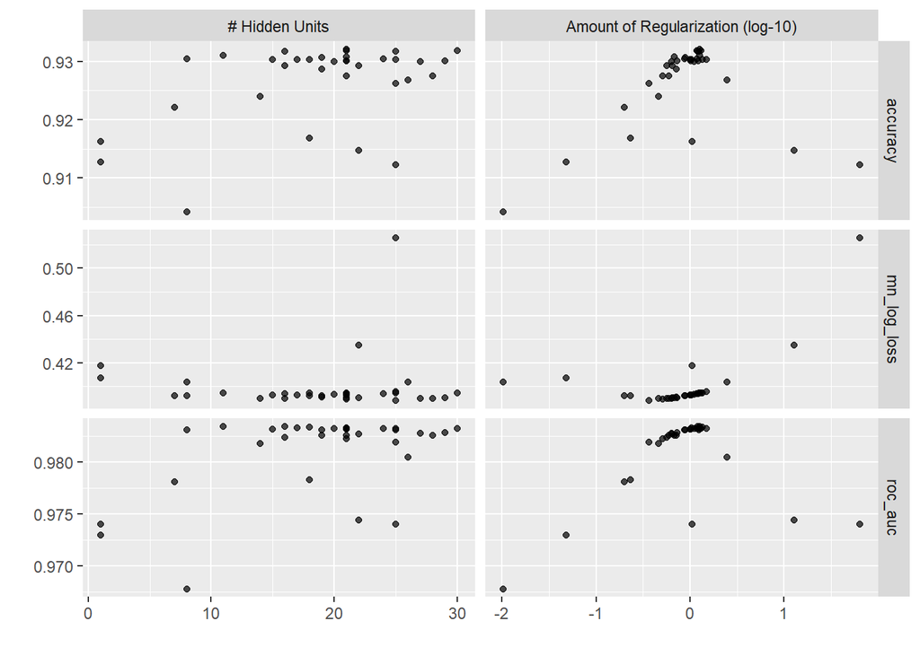

```r
autoplot(nn_res)
```

Find the best neural network model and fit on the train set:

```r
nn_best_roc_params <- nn_res %>% select_best('roc_auc')

final_nn_wflow <- nnet_wflow %>%
  finalize_workflow(nn_best_roc_params)

final_nn_fit <- final_nn_wflow %>%
  fit_resamples(cv_folds,
                metrics = my_metrics,
                control = control_resamples(save_pred = TRUE))
final_nn_fit %>% collect_metrics()
```

```
## # A tibble: 3 x 6
##   .metric     .estimator  mean     n std_err .config
##   <chr>       <chr>      <dbl> <int>   <dbl> <chr>
## 1 accuracy    binary     0.930    15 0.00336 Preprocessor1_Model1
## 2 mn_log_loss binary     0.394    15 0.00217 Preprocessor1_Model1
## 3 roc_auc     binary     0.983    15 0.00138 Preprocessor1_Model1
```

```r
final_nn_model <- final_nn_fit <- final_nn_wflow %>%  fit(ready_v_A)
```

Add the result to summary:

```r
all_cv_summaries <- all_cv_summaries %>%
  bind_rows(nn_res %>% collect_metrics(summarize = TRUE) %>%
              inner_join(nn_best_roc_params %>%
                           mutate(keep_these = 'yes'),
                         by = names(nn_best_roc_params)) %>%
              select(-keep_these) %>%
              mutate(wflow_id = "nnet"))

all_cv_results <- all_cv_results %>%
  bind_rows(nn_res %>% collect_metrics(summarize = FALSE) %>%
              inner_join(nn_best_roc_params %>%
                           mutate(keep_these = 'yes'),
                         by = names(nn_best_roc_params)) %>%
              select(-keep_these) %>%
              mutate(wflow_id = "nnet"))
```

Save the best neural network model:

```r
summary(final_nn_model)
```

```
##         Length Class      Mode
## pre     2      stage_pre  list
## fit     2      stage_fit  list
## post    1      stage_post list
## trained 1      -none-     logical
```

```r
final_nn_model %>% readr::write_rds("neural_network_regression_x.rds")
```

### Random forest

Define the model and the workflow:

```r
rf_spec <- rand_forest(mtry = tune(), min_n = tune(), trees = 500) %>%
  set_engine("ranger") %>%
  set_mode('classification')

stan_add <- recipe(outcome ~ ., data = ready_v_A)
rf_wflow <- workflow() %>%
  add_model(rf_spec) %>%
  add_recipe(stan_add)
```

Tune the model using Bayesian optimization:

```r
rf_set <-  rf_spec %>% parameters(rf_wflow) %>% finalize(ready_v_A)

set.seed(2021)
rf_res <- rf_wflow %>%
  tune_bayes(resamples = cv_folds,
             param_info = rf_set,
             metrics = my_metrics,
             initial = 5,
             iter = 20,
             control = control_bayes(no_improve = 10, verbose = TRUE))
```

```
## >  Generating a set of 5 initial parameter results
```

```
## √ Initialization complete
```

```
## Optimizing accuracy using the expected improvement
```

```
## -- Iteration 1 -----------------------------------------------------------------
```

```
## i Current best:      accuracy=0.9336 (@iter 0)
```

```
## i Gaussian process model
```

```
## √ Gaussian process model
```

```
## i Generating 1551 candidates
```

```
## i Predicted candidates
```

```
## i mtry=14, min_n=39
```

```
## i Estimating performance
```

```
## √ Estimating performance
```

```
## (x) Newest results:  accuracy=0.9293 (+/-0.00363)
```

```
## -- Iteration 2 -----------------------------------------------------------------
```

```
## i Current best:      accuracy=0.9336 (@iter 0)
```

```
## i Gaussian process model
```

```
## √ Gaussian process model
```

```
## i Generating 1551 candidates
```

```
## i Predicted candidates
```

```
## i mtry=13, min_n=7
```

```
## i Estimating performance
```

```
## √ Estimating performance
```

```
## <3 Newest results:   accuracy=0.934 (+/-0.00312)
```

```
## -- Iteration 3 -----------------------------------------------------------------
```

```
## i Current best:      accuracy=0.934 (@iter 2)
```

```
## i Gaussian process model
```

```
## √ Gaussian process model
```

```
## i Generating 1552 candidates
```

```
## i Predicted candidates
```

```
## i mtry=11, min_n=2
```

```
## i Estimating performance
```

```
## √ Estimating performance
```

```
## <3 Newest results:   accuracy=0.9343 (+/-0.00305)
```

```
## -- Iteration 4 -----------------------------------------------------------------
```

```
## i Current best:      accuracy=0.9343 (@iter 3)
```

```
## i Gaussian process model
```

```
## √ Gaussian process model
```

```
## i Generating 1540 candidates
```

```
## i Predicted candidates
```

```
## i mtry=12, min_n=2
```

```
## i Estimating performance
```

```
## √ Estimating performance
```

```
## (x) Newest results:  accuracy=0.9322 (+/-0.00353)
```

```
## -- Iteration 5 -----------------------------------------------------------------
```

```
## i Current best:      accuracy=0.9343 (@iter 3)
```

```
## i Gaussian process model
```

```
## √ Gaussian process model
```

```
## i Generating 1548 candidates
```

```
## i Predicted candidates
```

```
## i mtry=13, min_n=39
```

```
## i Estimating performance
```

```
## √ Estimating performance
```

```
## (x) Newest results:  accuracy=0.9301 (+/-0.00371)
```

```
## -- Iteration 6 -----------------------------------------------------------------
```

```
## i Current best:      accuracy=0.9343 (@iter 3)
```

```
## i Gaussian process model
```

```
## √ Gaussian process model
```

```
## i Generating 1529 candidates
```

```
## i Predicted candidates
```

```
## i mtry=10, min_n=2
```

```
## i Estimating performance
```

```
## √ Estimating performance
```

```
## (x) Newest results:  accuracy=0.9336 (+/-0.00315)
```

```
## -- Iteration 7 -----------------------------------------------------------------
```

```
## i Current best:      accuracy=0.9343 (@iter 3)
```

```
## i Gaussian process model
```

```
## √ Gaussian process model
```

```
## i Generating 1537 candidates
```

```
## i Predicted candidates
```

```
## i mtry=14, min_n=2
```

```
## i Estimating performance
```

```
## √ Estimating performance
```

```
## <3 Newest results:   accuracy=0.9347 (+/-0.00314)
```

```
## -- Iteration 8 -----------------------------------------------------------------
```

```
## i Current best:      accuracy=0.9347 (@iter 7)
```

```
## i Gaussian process model
```

```
## √ Gaussian process model
```

```
## i Generating 1548 candidates
```

```
## i Predicted candidates
```

```
## i mtry=16, min_n=2
```

```
## i Estimating performance
```

```
## √ Estimating performance
```

```
## (x) Newest results:  accuracy=0.9326 (+/-0.00337)
```

```
## -- Iteration 9 -----------------------------------------------------------------
```

```
## i Current best:      accuracy=0.9347 (@iter 7)
```

```
## i Gaussian process model
```

```
## √ Gaussian process model
```

```
## i Generating 1547 candidates
```

```
## i Predicted candidates
```

```
## i mtry=14, min_n=9
```

```
## i Estimating performance
```

```
## √ Estimating performance
```

```
## (x) Newest results:  accuracy=0.9324 (+/-0.00369)
```

```
## -- Iteration 10 ----------------------------------------------------------------
```

```
## i Current best:      accuracy=0.9347 (@iter 7)
```

```
## i Gaussian process model
```

```
## √ Gaussian process model
```

```
## i Generating 1532 candidates
```

```
## i Predicted candidates
```

```
## i mtry=11, min_n=7
```

```
## i Estimating performance
```

```
## √ Estimating performance
```

```
## (x) Newest results:  accuracy=0.9331 (+/-0.00316)
```

```
## -- Iteration 11 ----------------------------------------------------------------
```

```
## i Current best:      accuracy=0.9347 (@iter 7)
```

```
## i Gaussian process model
```

```
## √ Gaussian process model
```

```
## i Generating 1534 candidates
```

```
## i Predicted candidates
```

```
## i mtry=12, min_n=15
```

```
## i Estimating performance
```

```
## √ Estimating performance
```

```
## (x) Newest results:  accuracy=0.9336 (+/-0.003)
```

```
## -- Iteration 12 ----------------------------------------------------------------
```

```
## i Current best:      accuracy=0.9347 (@iter 7)
```

```
## i Gaussian process model
```

```
## √ Gaussian process model
```

```
## i Generating 1529 candidates
```

```
## i Predicted candidates
```

```
## i mtry=11, min_n=21
```

```
## i Estimating performance
```

```
## √ Estimating performance
```

```
## (x) Newest results:  accuracy=0.934 (+/-0.00334)
```

```
## -- Iteration 13 ----------------------------------------------------------------
```

```
## i Current best:      accuracy=0.9347 (@iter 7)
```

```
## i Gaussian process model
```

```
## √ Gaussian process model
```

```
## i Generating 1523 candidates
```

```
## i Predicted candidates
```

```
## i mtry=10, min_n=20
```

```
## i Estimating performance
```

```
## √ Estimating performance
```

```
## (x) Newest results:  accuracy=0.9329 (+/-0.00358)
```

```
## -- Iteration 14 ----------------------------------------------------------------
```

```
## i Current best:      accuracy=0.9347 (@iter 7)
```

```
## i Gaussian process model
```

```
## √ Gaussian process model
```

```
## i Generating 1529 candidates
```

```
## i Predicted candidates
```

```
## i mtry=15, min_n=2
```

```
## i Estimating performance
```

```
## √ Estimating performance
```

```
## (x) Newest results:  accuracy=0.9333 (+/-0.0032)
```

```
## -- Iteration 15 ----------------------------------------------------------------
```

```
## i Current best:      accuracy=0.9347 (@iter 7)
```

```
## i Gaussian process model
```

```
## √ Gaussian process model
```

```
## i Generating 1534 candidates
```

```
## i Predicted candidates
```

```
## i mtry=18, min_n=2
```

```
## i Estimating performance
```

```
## √ Estimating performance
```

```
## (x) Newest results:  accuracy=0.9314 (+/-0.00344)
```

```
## -- Iteration 16 ----------------------------------------------------------------
```

```
## i Current best:      accuracy=0.9347 (@iter 7)
```

```
## i Gaussian process model
```

```
## √ Gaussian process model
```

```
## i Generating 1525 candidates
```

```
## i Predicted candidates
```

```
## i mtry=10, min_n=35
```

```
## i Estimating performance
```

```
## √ Estimating performance
```

```
## (x) Newest results:  accuracy=0.9308 (+/-0.00337)
```

```
## -- Iteration 17 ----------------------------------------------------------------
```

```
## i Current best:      accuracy=0.9347 (@iter 7)
```

```
## i Gaussian process model
```

```
## √ Gaussian process model
```

```
## i Generating 1537 candidates
```

```
## i Predicted candidates
```

```
## i mtry=12, min_n=25
```

```
## i Estimating performance
```

```
## √ Estimating performance
```

```
## (x) Newest results:  accuracy=0.9324 (+/-0.00333)
```

```
## ! No improvement for 10 iterations; returning current results.
```

Visualize the result:

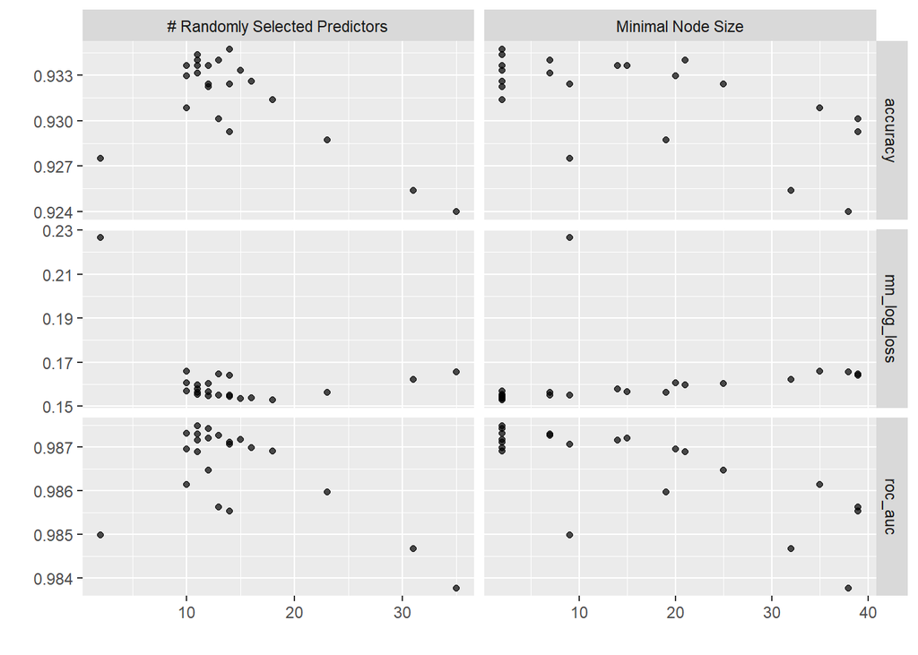

```r
rf_res %>% autoplot()
```

Find the best random forest model and fit on the train set:

```r
rf_best_roc_params <- rf_res %>% select_best('roc_auc')

final_rf_spec <- rand_forest(mtry = rf_best_roc_params$mtry,
                              min_n = rf_best_roc_params$min_n,
                              trees = 500) %>%
  set_engine('ranger', importance = 'impurity') %>%
  set_mode('classification')

final_rf_wflow <- workflow() %>%
  add_model(final_rf_spec) %>%
  add_recipe(stan_add)

set.seed(2021)
final_rf_model <-  final_rf_wflow %>%  fit(ready_v_A)
```

Add to summary:

```r
all_cv_summaries <- all_cv_summaries %>%
  bind_rows(rf_res %>% collect_metrics(summarize = TRUE) %>%
              inner_join(rf_best_roc_params %>%
                           mutate(keep_these = 'yes'),
                         by = names(rf_best_roc_params)) %>%
              select(-keep_these) %>%
              mutate(wflow_id = "rf"))

all_cv_results <- all_cv_results %>%
  bind_rows(rf_res %>% collect_metrics(summarize = FALSE) %>%
              inner_join(rf_best_roc_params %>%
                           mutate(keep_these = 'yes'),
                         by = names(rf_best_roc_params)) %>%
              select(-keep_these) %>%
              mutate(wflow_id = "rf"))
```

### Gradient boosted trees

Create gradient boosted trees:

```r
xgb_spec <- boost_tree(tree_depth = tune(), learn_rate = tune(),
                       trees = tune(), mtry = tune(), sample_size = tune()) %>%
  set_engine("xgboost") %>%
  set_mode("classification")
```

Define workflow:

```r
xgb_wflow <- workflow() %>%
  add_model(xgb_spec) %>%
  add_recipe(stan_add)
```

Tune gradient boosted trees using Bayesian optimization:

```r
xgb_set <- xgb_wflow %>% parameters() %>% finalize(ready_v_A)

set.seed(2021)
xgb_res <- xgb_wflow %>%
  tune_bayes(resamples = cv_folds,
             param_info = xgb_set,
             initial = 5,
             iter = 20,
             metrics = my_metrics,
             control = control_bayes(no_improve = 10, verbose = TRUE))
```

```
## ! There are 5 tuning parameters and 5 grid points were requested. This is
##   likely to cause numerical issues in the first few search iterations.
```

```
## >  Generating a set of 5 initial parameter results
```

```
## √ Initialization complete
```

```
## Optimizing accuracy using the expected improvement
```

```
## -- Iteration 1 -----------------------------------------------------------------
```

```
## i Current best:      accuracy=0.937 (@iter 0)
```

```
## i Gaussian process model
```

```
## ! The Gaussian process model is being fit using 5 features but only has 5
##   data points to do so. This may cause errors or a poor model fit.
```

```
## √ Gaussian process model
```

```
## i Generating 5000 candidates
```

```
## i Predicted candidates
```

```
## i mtry=27, trees=1978, tree_depth=9, learn_rate=0.084, sample_size=0.599
```

```
## i Estimating performance
```

```
## √ Estimating performance
```

```
## (x) Newest results:  accuracy=0.9328 (+/-0.00211)
```

```
## -- Iteration 2 -----------------------------------------------------------------
```

```
## i Current best:      accuracy=0.937 (@iter 0)
```

```
## i Gaussian process model
```

```
## ! The Gaussian process model is being fit using 5 features but only has 6
##   data points to do so. This may cause errors or a poor model fit.
```

```
## √ Gaussian process model
```

```
## i Generating 5000 candidates
```

```
## i Predicted candidates
```

```
## i mtry=1, trees=1941, tree_depth=11, learn_rate=1.02e-10, sample_size=0.235
```

```
## i Estimating performance
```

```
## √ Estimating performance
```

```
## (x) Newest results:  accuracy=0.6454 (+/-0.0104)
```

```
## -- Iteration 3 -----------------------------------------------------------------
```

```
## i Current best:      accuracy=0.937 (@iter 0)
```

```
## i Gaussian process model
```

```
## √ Gaussian process model
```

```
## i Generating 5000 candidates
```

```
## i Predicted candidates
```

```
## i mtry=1, trees=169, tree_depth=11, learn_rate=0.0944, sample_size=0.695
```

```
## i Estimating performance
```

```
## √ Estimating performance
```

```
## (x) Newest results:  accuracy=0.9271 (+/-0.00402)
```

```
## -- Iteration 4 -----------------------------------------------------------------
```

```
## i Current best:      accuracy=0.937 (@iter 0)
```

```
## i Gaussian process model
```

```
## √ Gaussian process model
```

```
## i Generating 5000 candidates
```

```
## i Predicted candidates
```

```
## i mtry=40, trees=1758, tree_depth=9, learn_rate=1.02e-10, sample_size=0.1
```

```
## i Estimating performance
```

```
## √ Estimating performance
```

```
## (x) Newest results:  accuracy=0.8945 (+/-0.00417)
```

```
## -- Iteration 5 -----------------------------------------------------------------
```

```
## i Current best:      accuracy=0.937 (@iter 0)
```

```
## i Gaussian process model
```

```
## √ Gaussian process model
```

```
## i Generating 5000 candidates
```

```
## i Predicted candidates
```

```
## i mtry=31, trees=1604, tree_depth=10, learn_rate=2.49e-05, sample_size=0.153
```

```
## i Estimating performance
```

```
## √ Estimating performance
```

```
## (x) Newest results:  accuracy=0.9266 (+/-0.00314)
```

```
## -- Iteration 6 -----------------------------------------------------------------
```

```
## i Current best:      accuracy=0.937 (@iter 0)
```

```
## i Gaussian process model
```

```
## √ Gaussian process model
```

```
## i Generating 5000 candidates
```

```
## i Predicted candidates
```

```
## i mtry=6, trees=1980, tree_depth=10, learn_rate=0.00134, sample_size=0.128
```

```
## i Estimating performance
```

```
## √ Estimating performance
```

```
## (x) Newest results:  accuracy=0.9271 (+/-0.00238)
```

```
## -- Iteration 7 -----------------------------------------------------------------
```

```
## i Current best:      accuracy=0.937 (@iter 0)
```

```
## i Gaussian process model
```

```
## √ Gaussian process model
```

```
## i Generating 5000 candidates
```

```
## i Predicted candidates
```

```
## i mtry=25, trees=252, tree_depth=7, learn_rate=8.97e-07, sample_size=1
```

```
## i Estimating performance
```

```
## √ Estimating performance
```

```
## (x) Newest results:  accuracy=0.9249 (+/-0.00349)
```

```
## -- Iteration 8 -----------------------------------------------------------------
```

```
## i Current best:      accuracy=0.937 (@iter 0)
```

```
## i Gaussian process model
```

```
## √ Gaussian process model
```

```
## i Generating 5000 candidates
```

```
## i Predicted candidates
```

```
## i mtry=42, trees=1911, tree_depth=1, learn_rate=5.97e-09, sample_size=0.581
```

```
## i Estimating performance
```

```
## √ Estimating performance
```

```
## (x) Newest results:  accuracy=0.8547 (+/-0.00421)
```

```
## -- Iteration 9 -----------------------------------------------------------------
```

```
## i Current best:      accuracy=0.937 (@iter 0)
```

```
## i Gaussian process model
```

```
## √ Gaussian process model
```

```
## i Generating 5000 candidates
```

```
## i Predicted candidates
```

```
## i mtry=5, trees=862, tree_depth=15, learn_rate=0.00145, sample_size=0.888
```

```
## i Estimating performance
```

```
## √ Estimating performance
```

```
## (x) Newest results:  accuracy=0.9335 (+/-0.00289)
```

```
## -- Iteration 10 ----------------------------------------------------------------
```

```
## i Current best:      accuracy=0.937 (@iter 0)
```

```
## i Gaussian process model
```

```
## √ Gaussian process model
```

```
## i Generating 5000 candidates
```

```
## i Predicted candidates
```

```
## i mtry=34, trees=798, tree_depth=15, learn_rate=5.17e-08, sample_size=0.655
```

```
## i Estimating performance
```

```
## √ Estimating performance
```

```
## (x) Newest results:  accuracy=0.9282 (+/-0.00399)
```

```
## ! No improvement for 10 iterations; returning current results.
```

Visualize the result:

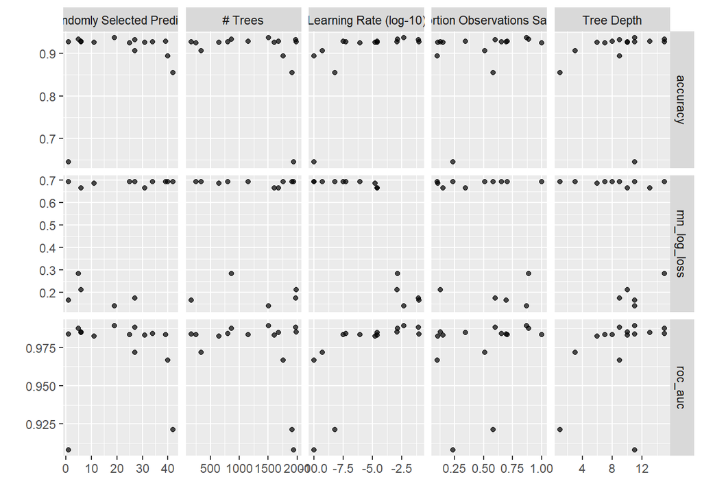

```r
autoplot(xgb_res)
```

Find the best gradient boosted trees model and fit on the train set:

```r
xgb_best_roc_params <- xgb_res %>% select_best('roc_auc')

final_xgb_wflow <- xgb_wflow %>%
  finalize_workflow(xgb_best_roc_params)

set.seed(2021)
final_xgb_resample <- final_xgb_wflow %>%
  fit_resamples(cv_folds,
                metrics = my_metrics,
                control = control_resamples(save_pred = TRUE))
final_xgb_resample %>% collect_metrics()
```

```
## # A tibble: 3 x 6
##   .metric     .estimator  mean     n  std_err .config
##   <chr>       <chr>      <dbl> <int>    <dbl> <chr>
## 1 accuracy    binary     0.937    15 0.00293  Preprocessor1_Model1
## 2 mn_log_loss binary     0.141    15 0.00544  Preprocessor1_Model1
## 3 roc_auc     binary     0.989    15 0.000796 Preprocessor1_Model1
```

```r
final_xgb_fit <- final_xgb_wflow %>%  fit(ready_v_A)
```

[output not shown]

Display the confusion matrix:

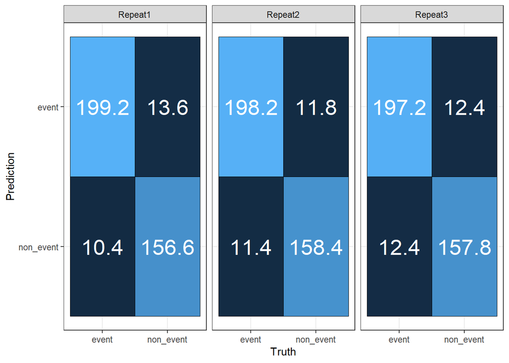

```r
final_xgb_resample %>% collect_predictions(summarize = FALSE) %>%
  group_nest(id, id2) %>%
  mutate(conf_mats = map(data,
                         ~ yardstick::conf_mat(.x, truth = outcome, estimate = .pred_class))) %>%
  mutate(conf_table = map(conf_mats, ~as.data.frame(.x$table))) %>%
  select(id, id2, conf_table) %>%
  tidyr::unnest(conf_table) %>%
  group_by(id, Prediction, Truth) %>%
  summarise(Freq = mean(Freq, na.rm = TRUE),
            .groups = 'drop') %>%
  mutate(Prediction = forcats::fct_rev(Prediction)) %>%
  ggplot(mapping = aes(x = Truth, y = Prediction)) +
  geom_tile(mapping = aes(fill = Freq),
            color = 'black') +
  geom_text(mapping = aes(label = round(Freq,2)),
            color = 'white', size = 7.5) +
  facet_wrap(~id) +
  theme_bw() +
  theme(legend.position = 'none')
```

Visualize the roc curve:

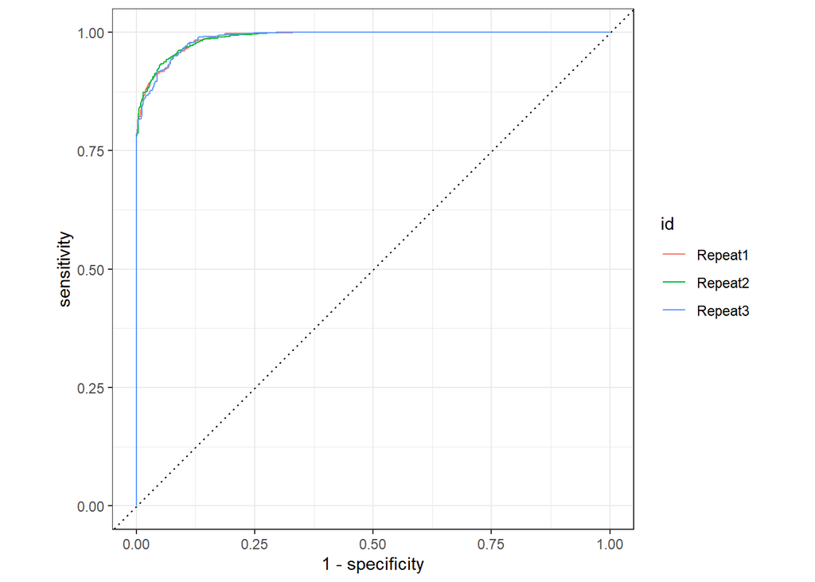

```r
final_xgb_resample %>% collect_predictions(summarize = FALSE) %>%
  group_by(id) %>%
  roc_curve(outcome, .pred_event) %>%
  autoplot()
```

Add to summary:

```r
all_cv_summaries <- all_cv_summaries %>%
  bind_rows(xgb_res %>% collect_metrics(summarize = TRUE) %>%
              inner_join(xgb_best_roc_params %>%
                           mutate(keep_these = 'yes'),
                         by = names(xgb_best_roc_params)) %>%
              select(-keep_these) %>%
              mutate(wflow_id = "xgb"))

all_cv_results <- all_cv_results %>%
  bind_rows(xgb_res %>% collect_metrics(summarize = FALSE) %>%
              inner_join(xgb_best_roc_params %>%
                           mutate(keep_these = 'yes'),
                         by = names(xgb_best_roc_params)) %>%
              select(-keep_these) %>%
              mutate(wflow_id = "xgb"))
```

### Support Vector Machine (SVM)

Define SVM model and workflow:

```r
svm_rbf_spec <- svm_rbf(cost = tune(), rbf_sigma = tune()) %>%
  set_engine("kernlab") %>%
  set_mode("classification")

svm_rbf_wflow <- workflow() %>%
  add_model(svm_rbf_spec) %>%
  add_recipe(bp_additive)
```

Tune SVM using racing with ANOVA:

```r
rbf_grid <- crossing(rbf_sigma = c(0.005, 0.01, 0.05, 0.1, 0.2, 0.4, 0.8, 1.25),
                     cost = c(0.01, 0.1, 1, 10, 100, 1000))

set.seed(2021)
svm_rbf_res <- tune_race_anova(
  svm_rbf_wflow,
  resamples = cv_folds,
  grid = rbf_grid,
  metrics = my_metrics
)
```

Visualize the result:

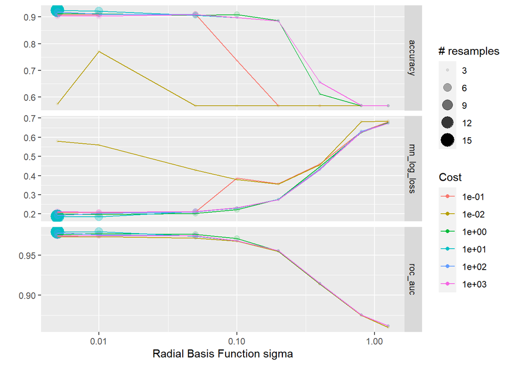

```r
autoplot(svm_rbf_res)
```

Identify the best tuning parameters and fit the final model:

```r
svm_best_params <- svm_rbf_res %>% select_best('roc_auc')

final_svm_rbf_wflow  <- svm_rbf_wflow  %>%
  finalize_workflow(svm_best_params)

set.seed(2021)
final_svm_fit <- final_svm_rbf_wflow %>%  fit(ready_v_A)
```

Add to summary:

```r
all_cv_summaries <- all_cv_summaries %>%
  bind_rows(svm_rbf_res %>% collect_metrics(summarize = TRUE) %>%
              inner_join(svm_best_params %>%
                           mutate(keep_these = 'yes'),
                         by = names(svm_best_params)) %>%
              select(-keep_these) %>%
              mutate(wflow_id = "svm rbf"))

all_cv_results <- all_cv_results %>%
  bind_rows(svm_rbf_res %>% collect_metrics(summarize = FALSE) %>%
              inner_join(svm_best_params %>%
                           mutate(keep_these = 'yes'),
                         by = names(svm_best_params)) %>%
              select(-keep_these) %>%
              mutate(wflow_id = "svm rbf"))
```

### K-nearest neighbors

Create model and workflow:

```r
knn_spec <- nearest_neighbor(neighbors = tune(), weight_func = tune()) %>%
  set_mode("classification") %>%
  set_engine("kknn")

knn_wflow <- workflow() %>%
  add_model(knn_spec) %>%
  add_recipe(bp_additive)
```

Tune KNN using racing with ANOVA:

```r
knn_grid <- crossing(neighbors = seq(1,100),
                     weight_func = c("rectangular", "triangular", "epanechnikov", "biweight", "triweight", "cos", "inv", "gaussian", "rank", "optimal"))

set.seed(2021)
knn_res <- tune_race_anova(
  knn_wflow,
  resamples = cv_folds,
  grid = knn_grid,
  metrics = my_metrics
)
```

Visualize the result:

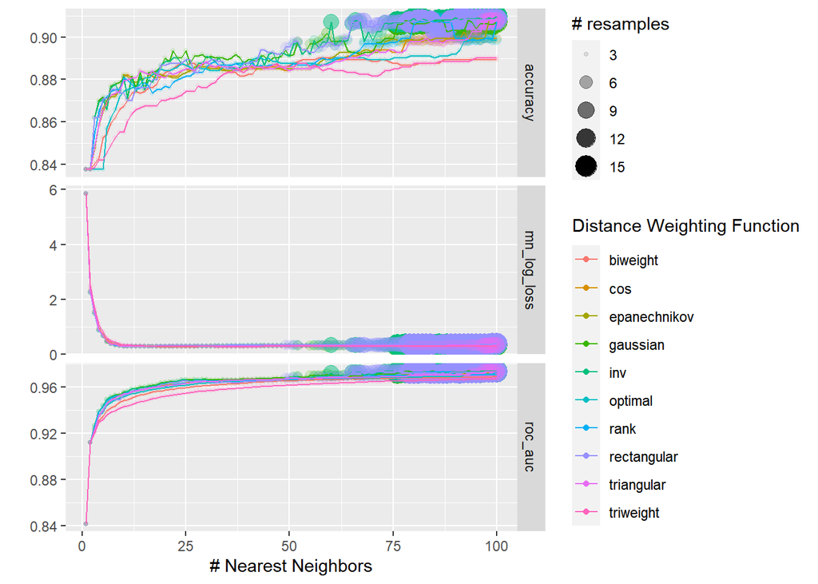

```r
autoplot(knn_res)
```

Identify the best tuning parameters and fit the final model:

```r
knn_best_roc_params <- knn_res %>% select_best('roc_auc')

final_knn_wflow  <- knn_wflow  %>%
  finalize_workflow(knn_best_roc_params)

set.seed(2021)
final_knn_model <- final_knn_wflow %>%  fit(ready_v_A)

final_knn_fit <- final_knn_wflow %>%
  fit_resamples(cv_folds,
                metrics = my_metrics)
final_knn_fit %>% collect_metrics()
```

```
## # A tibble: 3 x 6
##   .metric     .estimator  mean     n std_err .config
##   <chr>       <chr>      <dbl> <int>   <dbl> <chr>
## 1 accuracy    binary     0.909    15 0.00351 Preprocessor1_Model1
## 2 mn_log_loss binary     0.359    15 0.00366 Preprocessor1_Model1
## 3 roc_auc     binary     0.974    15 0.00185 Preprocessor1_Model1
```

Add to summary:

```r
all_cv_summaries <- all_cv_summaries %>%
  bind_rows(knn_res %>% collect_metrics(summarize = TRUE) %>%
              inner_join(knn_best_roc_params %>%
                           mutate(keep_these = 'yes'),
                         by = names(knn_best_roc_params)) %>%
              select(-keep_these) %>%
              mutate(wflow_id = "knn rbf"))

all_cv_results <- all_cv_results %>%
  bind_rows(knn_res %>% collect_metrics(summarize = FALSE) %>%
              inner_join(knn_best_roc_params %>%
                           mutate(keep_these = 'yes'),
                         by = names(knn_best_roc_params)) %>%
              select(-keep_these) %>%
              mutate(wflow_id = "knn rbf"))
```

### Model comparison

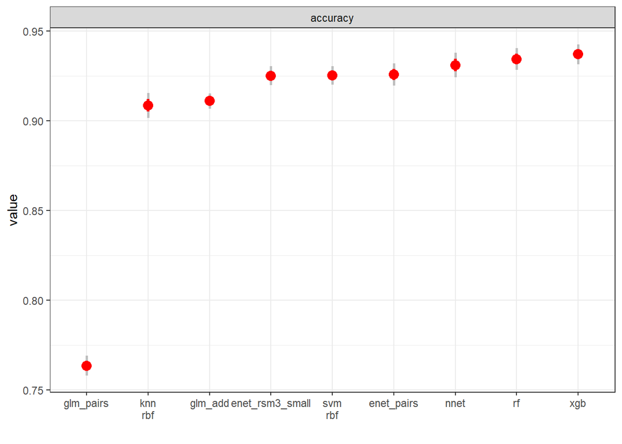

```r
all_cv_summaries %>%
  filter(.metric == "accuracy") %>%
  mutate(wflow_id = stringr::str_replace(wflow_id, " ", "\n")) %>%
  mutate(wflow_id = forcats::fct_reorder(wflow_id, mean, min)) %>%
  ggplot(mapping = aes(x = wflow_id)) +
  geom_linerange(mapping = aes(ymin = mean - 2*std_err,
                               ymax = mean + 2*std_err,
                               group = interaction(.metric, wflow_id)),
                 color = 'grey', size = 1.) +
  geom_linerange(mapping = aes(ymin = mean - 1*std_err,
                               ymax = mean + 1*std_err,
                               group = interaction(.metric, wflow_id)),
                 color = 'red', size = 1.2) +
  geom_point(mapping = aes(y = mean),
             color = 'red', size = 3.5) +
  facet_wrap(~.metric) +
  labs(x = '', y = 'value') +
  theme_bw()
```

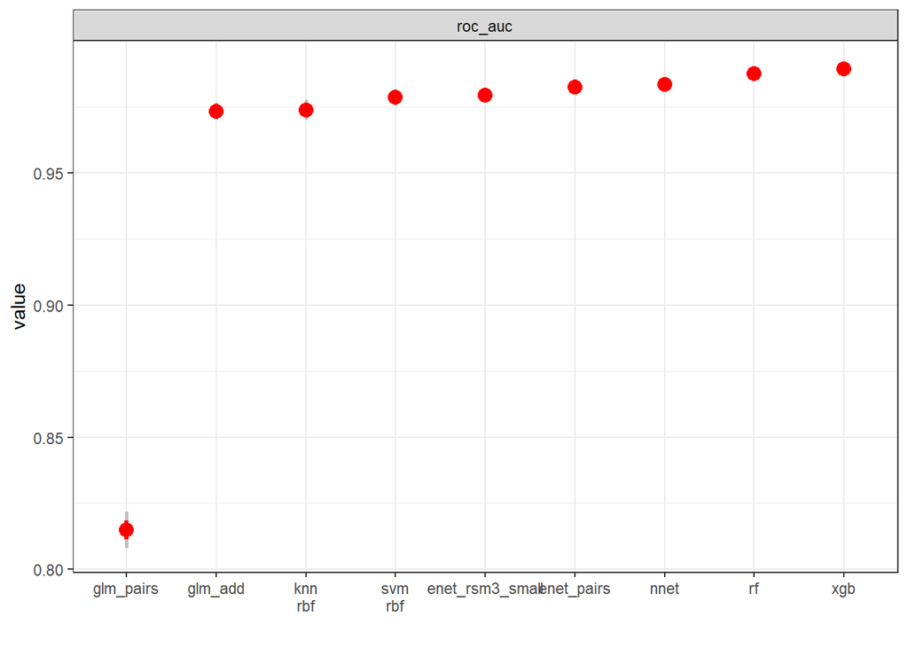

```r
all_cv_summaries %>%
  filter(.metric == "roc_auc") %>%
  mutate(wflow_id = stringr::str_replace(wflow_id, " ", "\n")) %>%
  mutate(wflow_id = forcats::fct_reorder(wflow_id, mean, min)) %>%
  ggplot(mapping = aes(x = wflow_id)) +
  geom_linerange(mapping = aes(ymin = mean - 2*std_err,
                               ymax = mean + 2*std_err,
                               group = interaction(.metric, wflow_id)),
                 color = 'grey', size = 1.) +
  geom_linerange(mapping = aes(ymin = mean - 1*std_err,
                               ymax = mean + 1*std_err,
                               group = interaction(.metric, wflow_id)),
                 color = 'red', size = 1.2) +
  geom_point(mapping = aes(y = mean),
             color = 'red', size = 3.5) +
  facet_wrap(~.metric) +
  labs(x = '', y = 'value') +
  theme_bw()
```

Based on the ROC plot, the Gradient boosted tree model still has the best performance. The second best is random forest model. Then third is neural network model.

Save the best model:

```r
final_xgb_fit %>% readr::write_rds("xgb_classification_v.rds")
```